# Geospatial Group Project

Streetlight Data- - Preliminary Work

Manjiri, Gayatri, Varvara

May 2025

**About This Document**

This file contains the pre-processing workflow for various UK streetlight datasets that were collected during the early stages of our project. The original intention was to compile and standardize streetlight data from multiple cities and regions across the UK into a single, unified dataset for comparative geospatial analysis. Each dataset came in a different format, with varying coordinate systems and metadata structures.

The primary goal here was to clean, filter, and convert all location data into a consistent format (latitude and longitude in WGS 84 / EPSG:4326), which would allow us to visualize and analyze them spatially. This included handling coordinates in Easting/Northing (British National Grid) and filtering out invalid or duplicate entries.

However, this line of analysis was later set aside in favor of a more focused approach. After reviewing data availability and refining our research scope, we decided to concentrate exclusively on Northern Ireland, where we had complete and consistent datasets for both crime incidents and streetlight locations. Therefore, the work in this document is not used in the final analysis but remains included as documentation of the initial exploratory effort. It reflects earlier trials and could still be useful for future extensions or comparative regional work.

To cross check if geolocation is correctly transformed: https://webapps.bgs.ac.uk/data/webservices/convertForm.cfm#bngToLatLng

# Packages

```r
library(sf)
library(dplyr)
library(ggplot2)
library(tmap)
library(readxl)
```

# Pre-processing Steps

For each dataset, we follow a standard cleaning and transformation procedure:

- Check if coordinate information is already in latitude/longitude format (EPSG:4326).
- If not, convert coordinates from British National Grid (EASTINGS and NORTHINGS, EPSG:27700) to WGS 84 (latitude and longitude).
- Remove unnecessary or irrelevant columns.
- Filter out missing or invalid coordinate entries (e.g., NA or zero values).
- Ensure that each streetlight entry is uniquely identified.
- Optionally, plot the cleaned data on a map for visual verification.

# Bradford

```r
Bradford_raw <- read_sf("Bradford_Street_Lighting.csv")

head(Bradford_raw)
```

```
## # A tibble: 6 × 16
##   X       Y     OBJECTID UNIT_ID UNIT_REF UNIT_TYPE UNIT_CODE UNIT_NAME EASTINGS
##   <chr>   <chr> <chr>    <chr>   <chr>    <chr>     <chr>     <chr>     <chr>
## 1 418188… 4329… 99947572 60584   00004F   31        SL        STREET L… 418188.3
## 2 418199… 4335… 99947573 60588   6        31        SL        STREET L… 418199.9
## 3 418200… 4335… 99947574 60589   2        31        SL        STREET L… 418200.5
## 4 418191… 4334… 99947575 60590   3        31        SL        STREET L… 418191.5
## 5 418178… 4334… 99947576 60591   4        31        SL        STREET L… 418178.5
## 6 418171… 4333… 99947577 60592   5        31        SL        STREET L… 418171.5
## # ℹ 7 more variables: NORTHINGS <chr>, USRN <chr>, ITEM_STATUS <chr>,
## #   LOCATION <chr>, STREETDESCRIPTION <chr>, DEFECT <chr>, CRNO <chr>
```

```r
n_distinct(Bradford_raw$OBJECTID)
```

```
## [1] 60030
```

ObjectIDs are all unique

```r
Bradford_raw %>% group_by(UNIT_CODE) %>% count()
```

```
## # A tibble: 1 × 2
## # Groups:   UNIT_CODE [1]
##   UNIT_CODE     n
##   <chr>     <int>
## 1 SL        60030
```

All are street lights.

```r
Bradford_raw %>%
  filter(is.na(EASTINGS) | EASTINGS == 0 | is.na(NORTHINGS) | NORTHINGS == 0) %>%
  nrow()
```

```
## [1] 46
```

Remove these

```r
Bradford_raw %>% group_by(DEFECT) %>% count()
```

```
## # A tibble: 2 × 2
## # Groups:   DEFECT [2]
##   DEFECT           n
##   <chr>        <int>
## 1 ""           56753
## 2 "OpenDefect"  3277
```

3277 have some defects. so we remove them.

```r
Bradford <- Bradford_raw %>%
  filter(DEFECT == "") %>%
  filter(!is.na(EASTINGS), EASTINGS != 0,
         !is.na(NORTHINGS), NORTHINGS != 0) %>%
  select(OBJECTID, EASTINGS, NORTHINGS)

head(Bradford)
```

```
## # A tibble: 6 × 3
##   OBJECTID EASTINGS NORTHINGS
##   <chr>    <chr>    <chr>
## 1 99947572 418188.3 432980.5
## 2 99947573 418199.9 433538.7
## 3 99947574 418200.5 433509.1
## 4 99947575 418191.5 433463.9
## 5 99947576 418178.5 433417
## 6 99947578 418164.3 433336.6
```

First we convert the dataframe to a spatial object using British National Grid coordinates (EPSG:27700)

```r
Bradford <- st_as_sf(Bradford, coords = c("EASTINGS", "NORTHINGS"), crs = 27700)
```

Then reproject the spatial object to WGS84 (EPSG:4326), which gives latitude and longitude.

```r
Bradford <- st_transform(Bradford, crs = 4326)
```

Extract the transformed coordinates (longitude, latitude) into a matrix.

```r
coords <- st_coordinates(Bradford)
```

Add the longitude and latitude columns back into the original dataframe.

```r
Bradford <- Bradford %>%
  mutate(longitude = coords[,1], latitude = coords[,2])

Bradford <- Bradford %>%
  rename(sl_id = OBJECTID) %>%
  mutate(place = "Bradford")

Bradford$sl_id <- as.character(Bradford$sl_id)
```

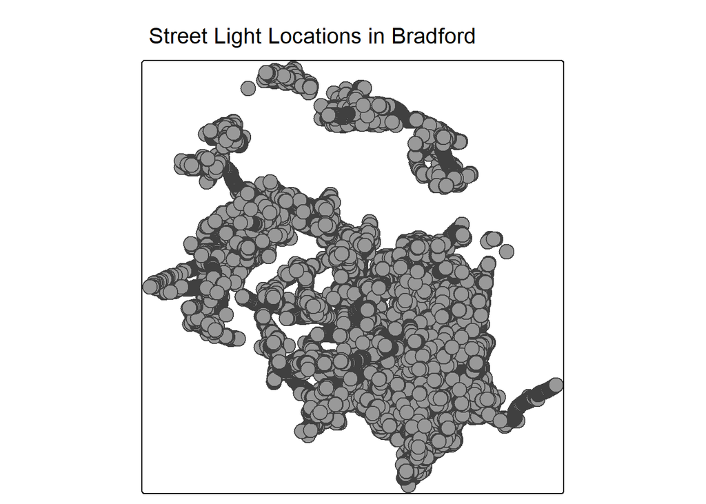

```r
qtm(Bradford, title = "Street Light Locations in Bradford")
```

```r
# qtm(Bradford,
#     dots.col = "darkgrey",
#     dots.size = 0.5,
#     title = "Street Light Locations in Bradford")
```

# Cambridgeshire

```r
Cambridgeshire_raw <- read.csv("Cambridgeshire_Street_Lighting.csv")

head(Cambridgeshire_raw)
```

```
##   unitid unitno                       location    fullstreet      town
## 1  42424  L2LAW                           OS 7     BEECH END ALCONBURY
## 2  38623  L5LAE                          OS 18   BRAMBLE END ALCONBURY
## 3  41981  L6LBW                          OP 42     BROOKSIDE ALCONBURY
## 4  45705  L2LAR                          OS 14 CHAPEL STREET ALCONBURY
## 5  43047  L3LAR                OP THE MALTINGS CHAPEL STREET ALCONBURY
## 6  40545  L4LAR CO JUNCTION  WITH SPINNEY LANE CHAPEL STREET ALCONBURY
##            owner Longitude Latitude
## 1 COUNTY COUNCIL -0.256205 52.36722
## 2 COUNTY COUNCIL -0.255627 52.36995
## 3 COUNTY COUNCIL -0.257649 52.36560
## 4 COUNTY COUNCIL -0.259464 52.36951
## 5 COUNTY COUNCIL -0.259083 52.36984
## 6 COUNTY COUNCIL -0.258805 52.37020
```

Latitute and Longitude already available. So just select the necessary columns.

```r
Cambridgeshire <- Cambridgeshire_raw %>%
  filter(!is.na(Latitude), Latitude != 0,
         !is.na(Longitude), Longitude != 0) %>%
  select(unitid, Longitude, Latitude) %>%
  rename(longitude = Longitude, latitude = Latitude, sl_id = unitid) %>%
  mutate(longitude = as.numeric(longitude),
         latitude = as.numeric(latitude)) %>%
  # Convert to sf *after* adding lon/lat
  st_as_sf(coords = c("longitude", "latitude"), crs = 4326)
```

```r
n_distinct(Cambridgeshire$sl_id)
```

```
## [1] 57678
```

All unique IDs. Since we do not have any information about defects. We assume all streetlights are in a working condition.

```r
# Extract coords as columns, without dropping sf class
Cambridgeshire <- Cambridgeshire %>%
  mutate(
    longitude = st_coordinates(.)[, 1],
    latitude = st_coordinates(.)[, 2]
  ) %>%
  mutate(place = "Cambridgeshire")


Cambridgeshire$sl_id <- as.character(Cambridgeshire$sl_id)
```

```
## [plot mode] fit legend/component: Some legend items or map compoments do not
## fit well, and are therefore rescaled.
## ℹ Set the tmap option `component.autoscale = FALSE` to disable rescaling.
```

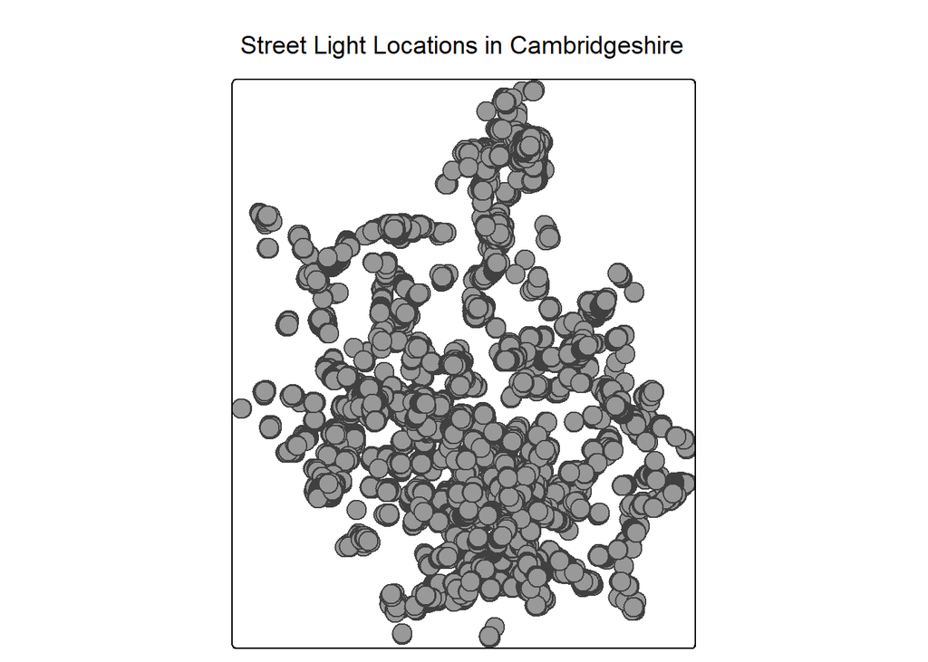

```r
#plot
qtm(Cambridgeshire, title = "Street Light Locations in Cambridgeshire")
```

# Camden

```r
Camden_raw <- read.csv("Camden_Street_Lighting.csv")

head(Camden_raw)
```

```
##   Local.Authority.Asset.Number        Street.Name                  Ward.Name
## 1                       247234 REGENT'S PARK ROAD              Primrose Hill
## 2                       248782   OSSULSTON STREET St Pancras and Somers Town
## 3                       242184    DALEHAM GARDENS                    Belsize
## 4                       242144         CHURCH ROW                    Frognal
## 5                       245414       CLARENCE WAY                 Haverstock
## 6                       246778     ARLINGTON ROAD               Regents Park
##   Postcode   Description Switch.Regime Wattage            Lamp.Type
## 1  NW1 8JA   S/O NO. 150         35/18      86 Generic LED Lighting
## 2  NW1 2DB J/W EUSTON RD         35/18     102 Generic LED Lighting
## 3  NW3 5BU     O/S NO 31         35/18      42 Generic LED Lighting
## 4  NW3 6UP     O/S NO 25         35/18     109 High Pressure Sodium
## 5  NW1 8DG     O/S NO 64         35/18      39 Generic LED Lighting
## 6  NW1 7ES        O/S 87         35/18     104    LED Street Lights
##       Column.Type Column.Height Heritage.Status Install.Date Easting Northing
```

[output cut: 27 more lines]

```r
Camden <- Camden_raw %>%
  filter(!is.na(Latitude), Latitude != 0,
         !is.na(Longitude), Longitude != 0) %>%
  select(Local.Authority.Asset.Number, Longitude, Latitude) %>%
  rename(longitude = Longitude, latitude = Latitude, sl_id = Local.Authority.Asset.Number) %>%
  mutate(longitude = as.numeric(longitude),
         latitude = as.numeric(latitude)) %>%

  # Convert to sf *after* adding lon/lat
  st_as_sf(coords = c("longitude", "latitude"), crs = 4326) %>%

  mutate(place="Camden")

# Extract coords as columns, without dropping sf class
Camden <- Camden %>%
  mutate(
    longitude = st_coordinates(.)[, 1],
    latitude = st_coordinates(.)[, 2]
  )

Camden$sl_id <- as.character(Camden$sl_id)
```

```r
n_distinct(Camden$sl_id)
```

```
## [1] 10659
```

All unique IDs. Since we do not have any information about defects. We assume all streetlights are in a working condition.

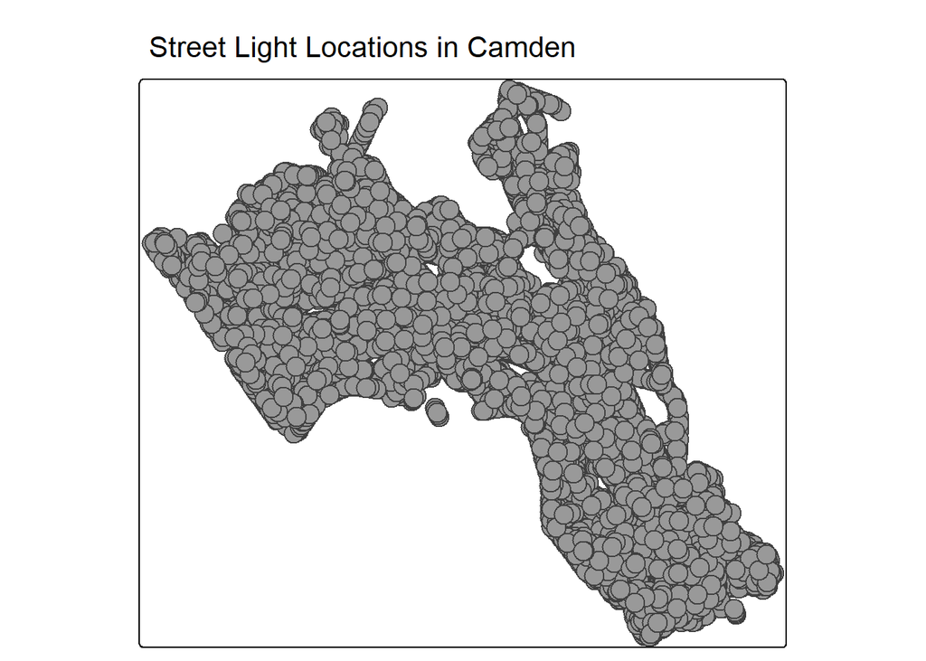

```r
#plot
qtm(Camden, title = "Street Light Locations in Camden")
```

# Leeds

```r
Leeds_raw <- read.csv("Leeds_Street_Lighting.csv")

head(Leeds_raw)
```

```
##   Unit.Number           Ward.Name   Road.Name       Location       Unit.Type
## 1      10A48   Adel & Wharfedale   Acorn Way         O/s 28   Street Lights
## 2      11A48   Adel & Wharfedale   Acorn Way   Btwn 18 & 20   Street Lights
## 3      12A48   Adel & Wharfedale   Acorn Way   Btwn 24 & 26   Street Lights
## 4      13A48   Adel & Wharfedale   Acorn Way         O/s 39   Street Lights
## 5      14A48   Adel & Wharfedale   Acorn Way         O/s 41   Street Lights
## 6      15A48   Adel & Wharfedale   Acorn Way         S/o 55   Street Lights
##   Number.of.Lamps  Easting Northing
## 1               1 425021.0 444712.0
## 2               1 425044.8 444698.7
## 3               1 425052.2 444713.7
## 4               1 425054.1 444741.3
## 5               1 425043.5 444750.0
## 6               1 425082.5 444758.6
```

```r
#unique(Leeds_raw$Unit.Type)
```

```r
Leeds <- Leeds_raw %>%
  filter(Unit.Type== " Street Lights ")  %>%
  filter(!is.na(Easting), Easting != 0, !is.na(Northing), Northing != 0) %>%
  filter(Number.of.Lamps == 1)  #consider locations with a single lamp
```

```r
Leeds %>%
  group_by(Unit.Number) %>%
  filter(n() > 1)
```

```
## # A tibble: 140 × 8
## # Groups:   Unit.Number [70]
##    Unit.Number Ward.Name    Road.Name Location Unit.Type Number.of.Lamps Easting
##    <chr>       <chr>        <chr>     <chr>    <chr>               <int>   <dbl>
##  1 1.00E+12    " Adel & Wh… " East C… " o/s 1… " Street…               1 427931.
##  2 1.00E+11    " Adel & Wh… " East C… " O/S 1… " Street…               1 427750.
##  3 1.00E+12    " Adel & Wh… " East C… " OPP 2… " Street…               1 427922.
##  4 1.00E+189   " Alwoodley… " Elmhur… " S/O H… " Street…               1 432458.
##  5 1.00E+189   " Alwoodley… " Elmhur… " S/O H… " Street…               1 432464.
##  6 1.00E+209   " Alwoodley… " Emvill… " O/s N… " Street…               1 433092.
##  7 1.00E+204   " Ardsley &… " Elwell… " OPP 1… " Street…               1 431239.
##  8 1.00E+144   " Armley "   " Elder … " OPP 5… " Street…               1 424308.
##  9 1.00E+144   " Armley "   " Elder … " AT EN… " Street…               1 424233.
## 10 1.00E+154   " Beeston &… " Elland… " O/S B… " Street…               1 428488.
## # ℹ 130 more rows
## # ℹ 1 more variable: Northing <dbl>
```

```r
Leeds %>%
  group_by(Unit.Number, Easting, Northing) %>%
  filter(n() > 1)
```

```
## # A tibble: 0 × 8
## # Groups:   Unit.Number, Easting, Northing [0]
## # ℹ 8 variables: Unit.Number <chr>, Ward.Name <chr>, Road.Name <chr>,
## #   Location <chr>, Unit.Type <chr>, Number.of.Lamps <int>, Easting <dbl>,
## #   Northing <dbl>
```

Unique combination of unit ID and the coordinates. So not removing anything.

```r
Leeds <- Leeds %>%
  select(Unit.Number, Easting, Northing) %>%
  mutate(place = "Leeds") %>%
  rename(sl_id = Unit.Number)
```

First we convert the dataframe to a spatial object using British National Grid coordinates (EPSG:27700)

```r
Leeds <- st_as_sf(Leeds, coords = c("Easting", "Northing"), crs = 27700)
```

Then reproject the spatial object to WGS84 (EPSG:4326), which gives latitude and longitude.

```r
Leeds <- st_transform(Leeds, crs = 4326)
```

Extract the transformed coordinates (longitude, latitude) into a matrix.

```r
coords <- st_coordinates(Leeds)
```

Add the longitude and latitude columns back into the original dataframe.

```r
Leeds <- Leeds %>%
  mutate(longitude = coords[,1], latitude = coords[,2])

Leeds$sl_id <- as.character(Leeds$sl_id)
```

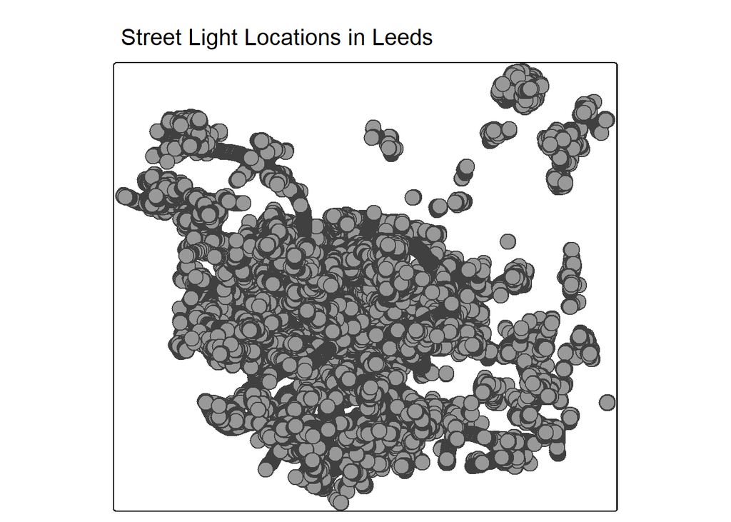

```r
qtm(Leeds, title = "Street Light Locations in Leeds")
```

# Barnet- London

```r
Barnet_raw <- read.csv("London_Barnet_Street_Lighting.csv")

head(Barnet_raw)
```

```
##   Asset_ID           Asset_type       Asset_category Asset_Position
## 1     7833 SL - Street Lighting B1 - Street Lighting       On Verge
## 2     7834 SL - Street Lighting B1 - Street Lighting       On Verge
## 3    12670 SL - Street Lighting B1 - Street Lighting   Back of Path
## 4    12671 SL - Street Lighting B1 - Street Lighting   Back of Path
## 5    12672 SL - Street Lighting B1 - Street Lighting   Back of Path
## 6    12673 SL - Street Lighting B1 - Street Lighting  Front of Path
##        Adress_number Road_description Asset_XCords Asset_YCords
## 1        Outside 104       ABBEY VIEW     521719.3     193333.9
## 2 Outside GREYSTANES       ABBEY VIEW     521700.2     193312.7
## 3          Outside 1       ABBEY VIEW     521751.2     193346.0
## 4          Outside 2       ABBEY VIEW     521778.1     193327.2
## 5         Outside 10       ABBEY VIEW     521812.2     193313.5
## 6         Opposite 7       ABBEY VIEW     521824.5     193291.7
##      Structure..Material.Label Structure..Height Structure..Install.Date
## 1 (FA1) Standard Tubular Steel                 6     01/01/1994 00:00:00
## 2 (FA1) Standard Tubular Steel                 6     05/06/2013 00:00:00
## 3 (NT1) Standard Tubular Steel                 6     18/06/2013 00:00:00
## 4 (NT1) Standard Tubular Steel                 6     18/06/2013 00:00:00
## 5 (NT1) Standard Tubular Steel                 6     18/06/2013 00:00:00
## 6 (NT1) Standard Tubular Steel                 6     18/06/2013 00:00:00
```

```r
#unique(Barnet_raw$Asset_type)
```

```r
Barnet <- Barnet_raw %>%
  filter(Asset_type %in% c( "SL - Street Lighting", "SL - Mounted Lighting")) %>%
  filter(!is.na(Asset_XCords), Asset_XCords != 0, !is.na(Asset_YCords), Asset_YCords != 0) %>%
  select(Asset_ID, Asset_XCords, Asset_YCords) %>%
  mutate(place = "Barnet") %>%
  rename(sl_id = Asset_ID)
```

```r
n_distinct(Barnet$sl_id)
```

```
## [1] 27714
```

All unique.

```r
# Convert to sf object (EPSG:27700 = British National Grid)
Barnet <- st_as_sf(Barnet, coords = c("Asset_XCords", "Asset_YCords"), crs = 27700)

# Transform to WGS84 (EPSG:4326) to get lat/lon
Barnet <- st_transform(Barnet, crs = 4326)

# Extract coordinates
coords <- st_coordinates(Barnet)

# Add back lat/lon columns to dataframe
Barnet <- Barnet %>%
  mutate(longitude = coords[, 1],
         latitude = coords[, 2])

Barnet$sl_id <- as.character(Barnet$sl_id)
```

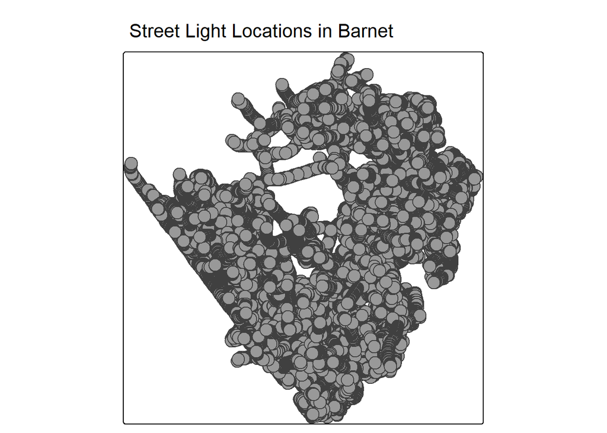

```r
qtm(Barnet, title = "Street Light Locations in Barnet")
```

# Redbridge

```r
Redbridge_raw <- read_xlsx("London_Redbridge_Street_Lighting.xlsx")

head(Redbridge_raw)
```

```
## # A tibble: 6 × 17
##   site_code site_name      plot_number feature_location feature_deadflag
##   <chr>     <chr>                <dbl> <chr>            <chr>
## 1 22300001  Whitehall Road    10001001 <NA>             N
## 2 22300001  Whitehall Road    10001002 <NA>             N
## 3 22300001  Whitehall Road    10001003 <NA>             N
## 4 22300001  Whitehall Road    10001004 <NA>             N
## 5 22300001  Whitehall Road    10001005 <NA>             N
## 6 22300001  Whitehall Road    10001006 O/S 191          N
## # ℹ 12 more variables: feature_type_code <chr>, feature_type_name <chr>,
## #   feature_group_code <chr>, feat_ext_1_easting <dbl>, feat_ext_1_north <dbl>,
## #   feat_ext_2_easting <dbl>, feat_ext_2_north <dbl>, feat_cent_east <dbl>,
## #   feat_cent_north <dbl>, central_asset_id <chr>, feature_start_date <dttm>,
## #   feature_end_date <dttm>
```

```r
unique(Redbridge_raw$feature_type_name)
```

```
## [1] "SL-Columns"                   "SL-Not Applicable - not used"
## [3] "SL-BO - Lights - Not Used"
```

```r
Redbridge <- Redbridge_raw %>%
  filter(feature_type_name == "SL-Columns") %>%
  filter(!is.na(feat_cent_east), feat_cent_east != 0, !is.na(feat_cent_north), feat_cent_north != 0) %>%
  select("central_asset_id", "feat_cent_east","feat_cent_north") %>%
  rename(sl_id = central_asset_id) %>%
  mutate(place = "Redbridge")
```

```r
n_distinct(Redbridge$sl_id)
```

```
## [1] 21030
```

All unique.

```r
head(Redbridge)
```

```
## # A tibble: 6 × 4
##   sl_id    feat_cent_east feat_cent_north place
##   <chr>             <dbl>           <dbl> <chr>
## 1 00122489        540394.         193026. Redbridge
## 2 00122490        540385.         193051. Redbridge
## 3 00122491        540354.         193046. Redbridge
## 4 00122492        540333.         193056. Redbridge
## 5 00122493        540315.         193064. Redbridge
## 6 00122494        540295.         193082. Redbridge
```

```r
# Convert to sf object (EPSG:27700 = British National Grid)
Redbridge <- st_as_sf(Redbridge, coords = c("feat_cent_east", "feat_cent_north"), crs = 27700)

# Transform to WGS84 (EPSG:4326) to get lat/lon
Redbridge <- st_transform(Redbridge, crs = 4326)

# Extract coordinates
coords <- st_coordinates(Redbridge)

# Add back lat/lon columns to dataframe
Redbridge <- Redbridge %>%
  mutate(longitude = coords[, 1],
         latitude = coords[, 2])

head(Redbridge)
```

```
## Simple feature collection with 6 features and 4 fields
## Geometry type: POINT
## Dimension:     XY
## Bounding box:  xmin: 0.02509175 ymin: 51.61856 xmax: 0.02649673 ymax: 51.61909
## Geodetic CRS:  WGS 84
## # A tibble: 6 × 5
##   sl_id    place                  geometry longitude latitude
##   <chr>    <chr>               <POINT [°]>     <dbl>    <dbl>
## 1 00122489 Redbridge (0.02649673 51.61856)    0.0265     51.6
## 2 00122490 Redbridge (0.02637681 51.61878)    0.0264     51.6
## 3 00122491 Redbridge (0.02593368 51.61875)    0.0259     51.6
## 4 00122492 Redbridge (0.02564173 51.61884)    0.0256     51.6
## 5 00122493 Redbridge (0.02537572 51.61891)    0.0254     51.6
## 6 00122494 Redbridge (0.02509175 51.61909)    0.0251     51.6
```

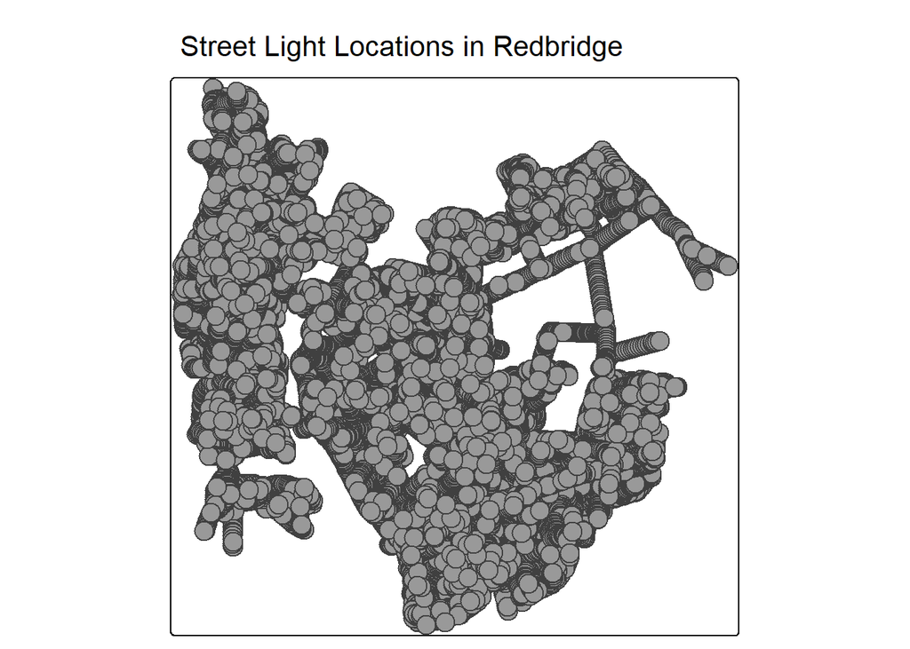

```r
qtm(Redbridge, title = "Street Light Locations in Redbridge")
```

# Manchester

```r
Manchester_raw <- read_xlsx("Manchester_Street_Lighting.xlsx")

head(Manchester_raw)
```

```
## # A tibble: 6 × 8
##   UNITID UNITTYPE UNITNO LOCATION           STREET        TOWN  EASTING NORTHING
##   <chr>  <chr>    <chr>  <chr>              <chr>         <chr>   <dbl>    <dbl>
## 1 000012 L        02     ON FOOT PATH       ABBEY COURT … MANC… 389139.  396559.
## 2 000015 L        11     OPP HOLMPARK ROAD  ABBEY HEY LA… MANC… 389491.  397150.
## 3 000016 L        12     C/O HOLMPARK ROAD  ABBEY HEY LA… MANC… 389513.  397144.
## 4 000017 L        13     JNC MONTANA SQUARE ABBEY HEY LA… MANC… 389498.  397127.
## 5 000021 L        16     OPP SUPERMARKET    ABBEY HEY LA… MANC… 389551.  397034.
## 6 000083 L        09     OPP MELVILLE CLOSE ABBEY HEY LA… MANC… 389477.  397187.
```

```r
Manchester <- Manchester_raw %>%
  filter(!is.na(EASTING), EASTING != 0, !is.na(NORTHING), NORTHING != 0) %>%
  select(UNITID, EASTING, NORTHING) %>%
  rename(sl_id = UNITID) %>%
  mutate(place = "Manchester")
```

```r
#First we convert the dataframe to a spatial object using British National Grid coordinates (EPSG:27700)
Manchester <- st_as_sf(Manchester, coords = c("EASTING", "NORTHING"), crs = 27700)



#Then reproject the spatial object to WGS84 (EPSG:4326), which gives latitude and longitude.
Manchester <- st_transform(Manchester, crs = 4326)


#Extract the transformed coordinates (longitude, latitude) into a matrix.
coords <- st_coordinates(Manchester)


#Add the longitude and latitude columns back into the original dataframe.

Manchester <- Manchester %>%
  mutate(longitude = coords[,1], latitude = coords[,2])

Manchester$sl_id <- as.character(Manchester$sl_id)
```

```r
qtm(Manchester, title = "Street Light Locations in Manchester")
```

```
## [plot mode] fit legend/component: Some legend items or map compoments do not
## fit well, and are therefore rescaled.
## ℹ Set the tmap option `component.autoscale = FALSE` to disable rescaling.
```

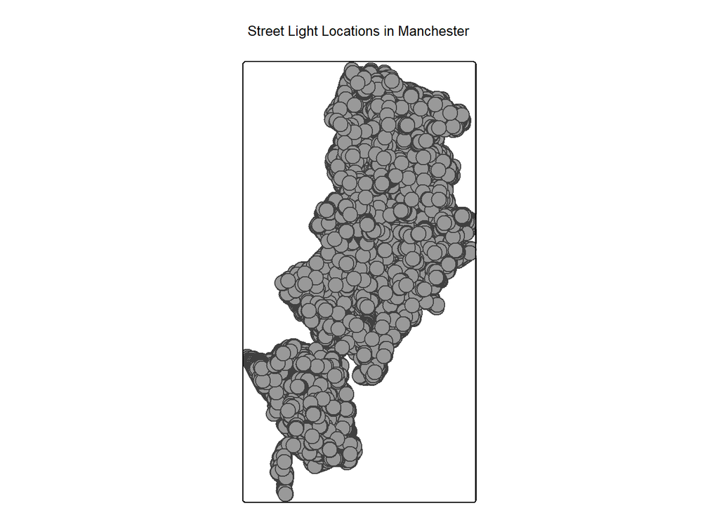

# York

```r
York_raw <- read.csv("York_Street_lighting.csv")

head(York_raw)
```

```
##           X        Y IIT_NE_ID LP_UNIQUE_REF
## 1 -1.132479 53.95586   3510445            12
## 2 -1.049859 53.95900   3510446         70834
## 3 -1.134394 53.99713   3510447         49223
## 4 -1.133719 53.99657   3510448         49233
## 5 -1.132897 53.99590   3510449         49243
## 6 -1.132238 53.99534   3510450         49252
##                                DESCRIPTION                    LOCATION
## 1 BELISHA BEACON (BB1) DANEBURY DRIVE ACOM               J/W THE GREEN
## 2 BELISHA BEACON (BB1) TANG HALL LANE HEWO                J/W LANG AVE
## 3 BELISHA BEACON (AP 7) SHIPTON ROAD SKELT ON ISLAND JCT FAIRFIELDS DR
## 4 BELISHA BEACON (AP 6) SHIPTON ROAD SKELT                  OPP COL 91
## 5 BELISHA BEACON (AP 5) SHIPTON ROAD SKELT                       O/S 4
## 6 BELISHA BEACON (AP 4) SHIPTON ROAD SKELT                   ON ISLAND
##        ROAD_NAME ROAD_NUMBER     USRN       WARD    PARISH UNIT_TYPE Latitude
## 1 DANEBURY DRIVE          NA 45800487      Acomb Non-Civil        BB 53.95586
## 2 TANG HALL LANE          NA 45801816  Hull Road Non-Civil        BB 53.95900
## 3   SHIPTON ROAD          NA 33300825 Rural West   Skelton        BB 53.99713
## 4   SHIPTON ROAD          NA 33300825 Rural West   Skelton        BB 53.99657
## 5   SHIPTON ROAD          NA 33300825 Rural West   Skelton        BB 53.99590
## 6   SHIPTON ROAD          NA 33300825 Rural West   Skelton        BB 53.99534
##   Longitude         DateCreatedCYC                  Item_Id
## 1 -1.132479 2024/06/04 03:01:52+00 652e884c3017fece401e4c37
## 2 -1.049859 2024/06/04 03:01:52+00 652e86d33017fece401b37d8
## 3 -1.134394 2024/06/04 03:01:52+00 652e86d33017fece401b3a38
## 4 -1.133719 2024/06/04 03:01:52+00 652e86d33017fece401b3a3c
## 5 -1.132897 2024/06/04 03:01:52+00 652e86d33017fece401b3a42
## 6 -1.132238 2024/06/04 03:01:52+00 652e86d33017fece401b3a46
```

```r
#unique(York_raw$UNIT_TYPE)
```

```r
n_distinct(York_raw$IIT_NE_ID)
```

```
## [1] 22218
```

All unique.

```r
York <- York_raw %>%
  filter(UNIT_TYPE == "SL") %>%
  filter(!is.na(Latitude), Latitude != 0,!is.na(Longitude), Longitude != 0) %>%
  select(Item_Id, Longitude, Latitude) %>%
  rename(longitude = Longitude, latitude = Latitude, sl_id = Item_Id) %>%
  mutate(longitude = as.numeric(longitude), latitude = as.numeric(latitude)) %>%

  # Convert to sf *after* adding lon/lat
  st_as_sf(coords = c("longitude", "latitude"), crs = 4326) %>%

  mutate(place="York")

# Extract coords as columns, without dropping sf class
York <- York %>%
  mutate(longitude = st_coordinates(.)[, 1],latitude = st_coordinates(.)[, 2])

York$sl_id <- as.character(York$sl_id)
```

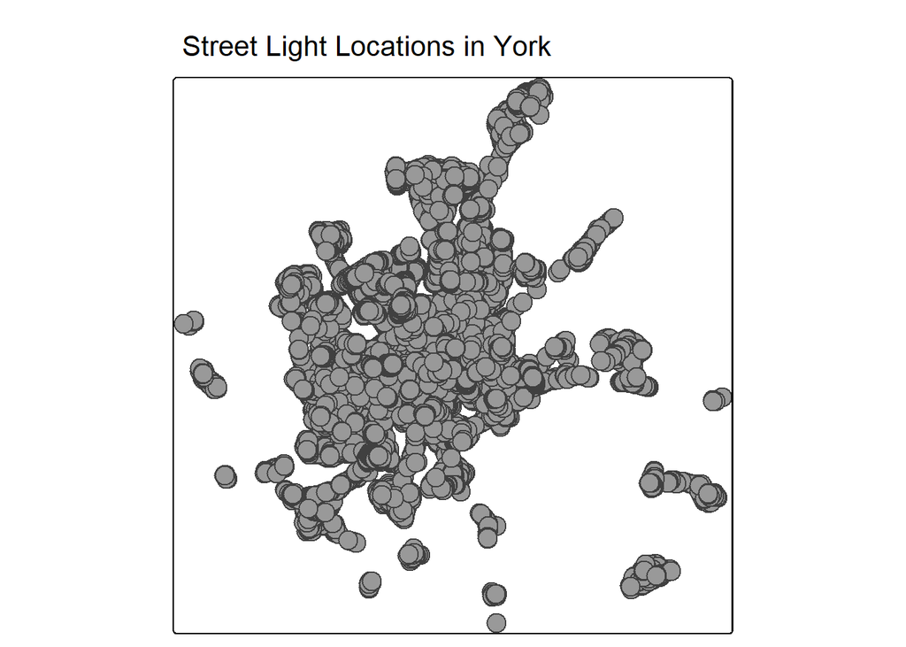

```r
qtm(York, title = "Street Light Locations in York")
```

# Northern Ireland

## Streetlight

```r
NI_raw <- read_xlsx("Northern_Ireland_Street_Lighting.xlsx")

head(NI_raw)
```

```
## # A tibble: 6 × 11
##     FID DIVISION_N ITEM_IDENT ITEM_TYPE_     STREET_DES EASTING NORTHING
##   <dbl> <chr>      <chr>      <chr>          <chr>        <dbl>    <dbl>
## 1     1 WESTERN    L1         LIGHTING_POINT ABBEY PARK 243130.  416895.
## 2     2 WESTERN    L2         LIGHTING_POINT ABBEY PARK 243131.  416873.
## 3     3 WESTERN    L3         LIGHTING_POINT ABBEY PARK 243126.  416852.
## 4     4 WESTERN    L4         LIGHTING_POINT ABBEY PARK 243093.  416868.
## 5     5 WESTERN    L5         LIGHTING_POINT ABBEY PARK 243108.  416875.
## 6     6 WESTERN    L6         LIGHTING_POINT ABBEY PARK 243107.  416884.
## # ℹ 4 more variables: END_DATE <dttm>, SECTION_UI <dbl>, x <dbl>, y <dbl>
```

```r
unique(NI_raw$ITEM_TYPE_)
```

```
## [1] "LIGHTING_POINT"
```

```r
n_distinct(NI_raw$FID)
```

```
## [1] 302146
```

All unique.

```r
NI <- NI_raw %>%
  filter(!is.na(EASTING), EASTING != 0, !is.na(NORTHING), NORTHING > 62) %>%
  select(FID, EASTING, NORTHING) %>%
  rename(sl_id = FID) %>%
  mutate(place = "Northern_Ireland")
```

```r
#First we convert the dataframe to a spatial object using British National Grid coordinates (EPSG:27700)
NI <- st_as_sf(NI, coords = c("EASTING", "NORTHING"), crs = 27700)


#Then reproject the spatial object to WGS84 (EPSG:4326), which gives latitude and longitude.
NI <- st_transform(NI, crs = 4326)


#Extract the transformed coordinates (longitude, latitude) into a matrix.
coords <- st_coordinates(NI)


#Add the longitude and latitude columns back into the original dataframe.
NI <- NI %>%
  mutate(longitude = coords[,1], latitude = coords[,2])

NI$sl_id <- as.character(NI$sl_id)
```

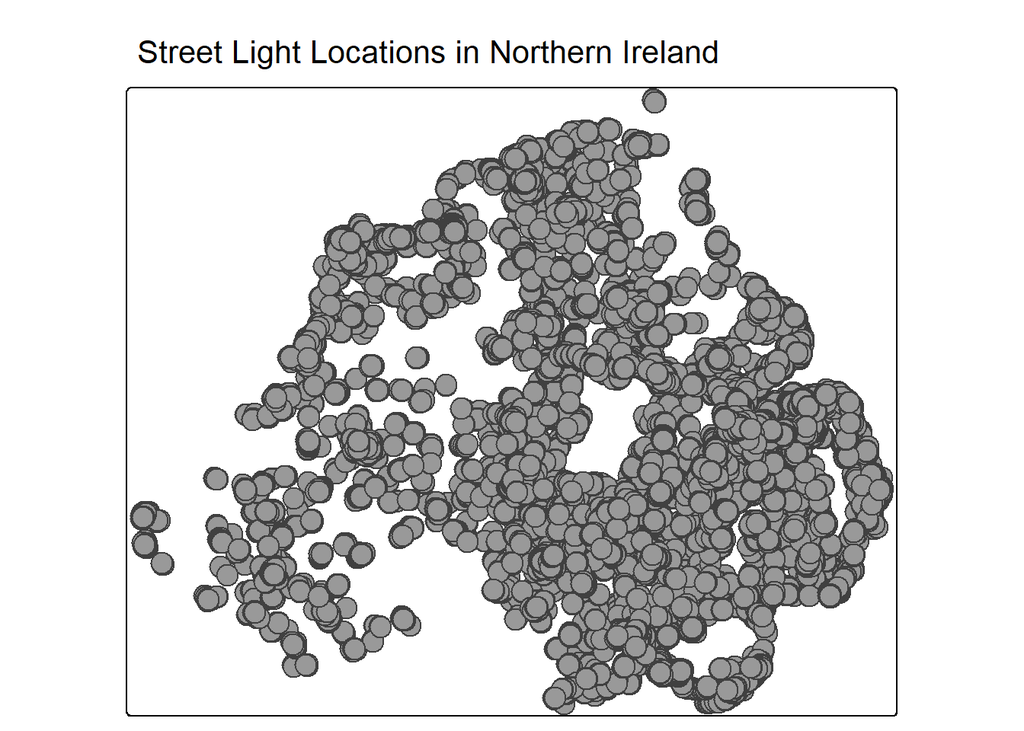

```r
qtm(NI, title = "Street Light Locations in Northern Ireland")
```

## kml file

A KML file (Keyhole Markup Language file) is a file format used to display geographic data in mapping software such as Google Earth, Google Maps, and QGIS. It stores points, lines, polygons, images, and 3D models along with metadata like names, descriptions, and styles.

```r
# Read the KML file
NI_kml <- st_read("force kmls/northern-ireland.kml")
# View basic structure
print(NI_kml)
```

```
## Simple feature collection with 1 feature and 2 fields
## Geometry type: MULTIPOLYGON
## Dimension:     XYZ
## Bounding box:  xmin: -8.624268 ymin: 53.89139 xmax: -5.119629 ymax: 55.44148
## z_range:       zmin: 0 zmax: 0
## Geodetic CRS:  WGS 84
##   Name Description                       geometry
## 1                  MULTIPOLYGON Z (((-5.723877...
```

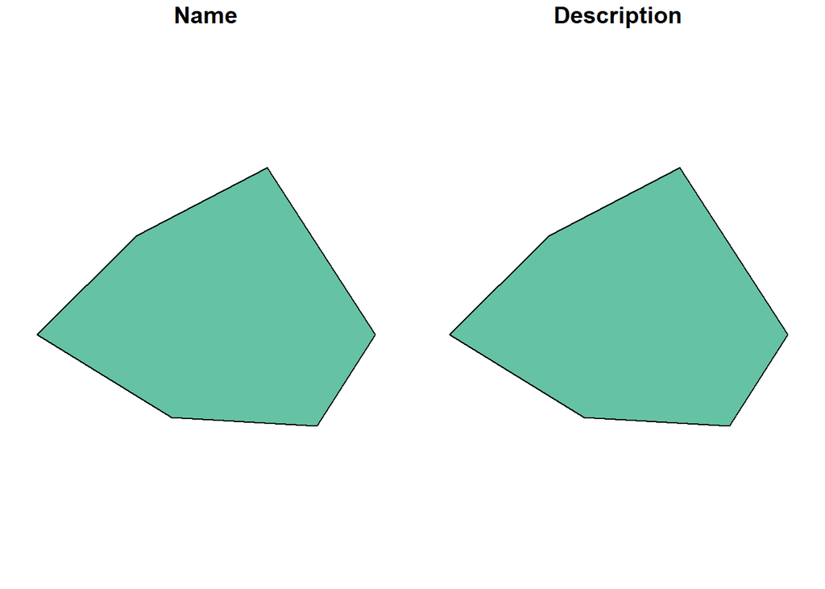

```r
plot(NI_kml)
```

```r
# List all layers in the KML file
st_layers("force kmls/northern-ireland.kml")
```

```
## Driver: KML
## Available layers:
##   layer_name    geometry_type features fields crs_name
## 1   Layer #0 3D Multi Polygon        1      2   WGS 84
```

```r
qtm(NI_kml, fill = "lightgrey", border.col = "darkblue") +
  qtm(NI, dots.col = "red", dots.size = 0.5, title = "Street Lights in NI")
```

```
## ── tmap v3 code detected ───────────────────────────────────────────────────────
```

```
## [v3->v4] `qtm()`: use `fill` instead of `dots.col`.
```

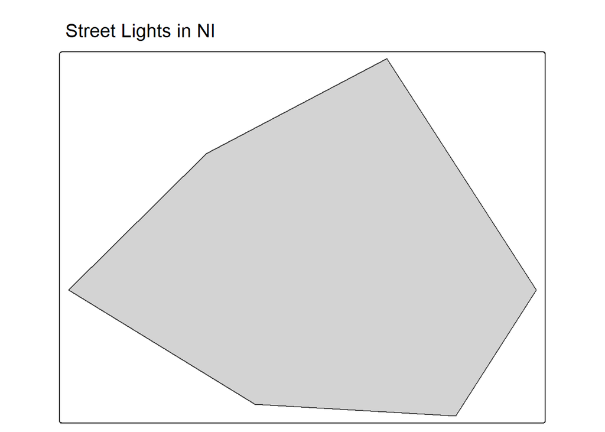

## GeoJSON

```r
NI_geo <- st_read("northern_ireland_police.geojson")
```

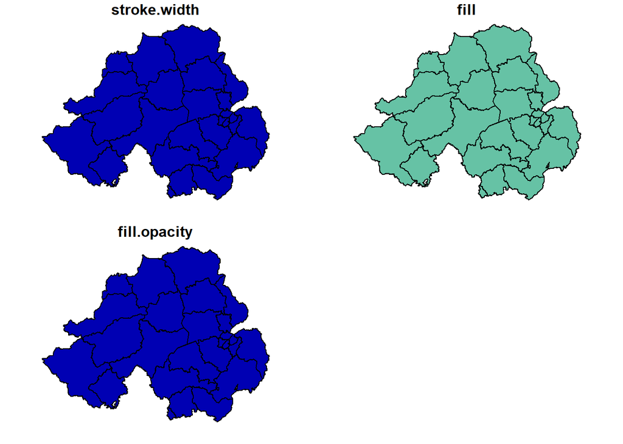

```r
plot(NI_geo)
```

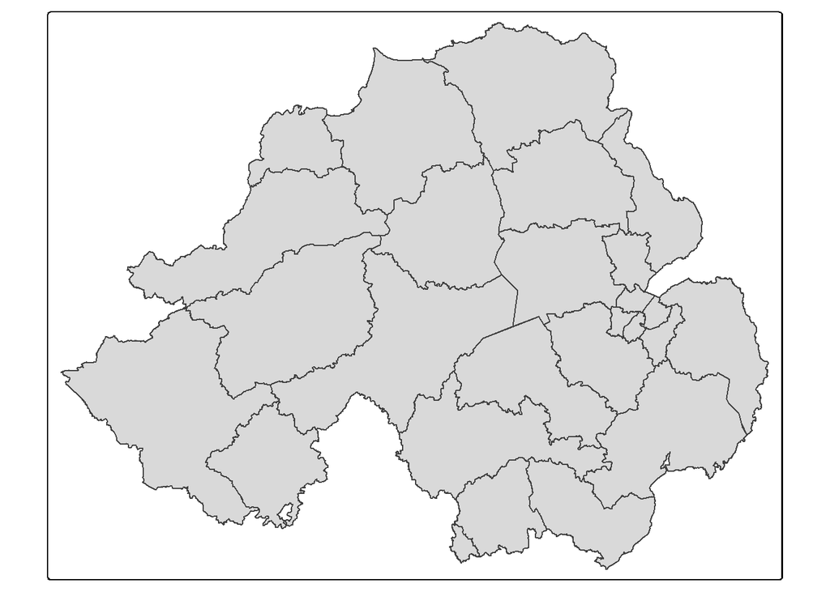

```r
qtm(NI_geo)
```

# Combine it all

```r
# Combine them into one master sf object

streetlights_all <- bind_rows(
  Barnet, Bradford, Cambridgeshire, Camden,
  Leeds, Manchester, Redbridge,York, NI)

write.csv(streetlights_all, "streetlights_all.csv", row.names = FALSE)
```

```r
class(streetlights_all)
```

```
## [1] "sf"         "data.frame"
```

```r
nrow(streetlights_all)
```

```
## [1] 652341
```

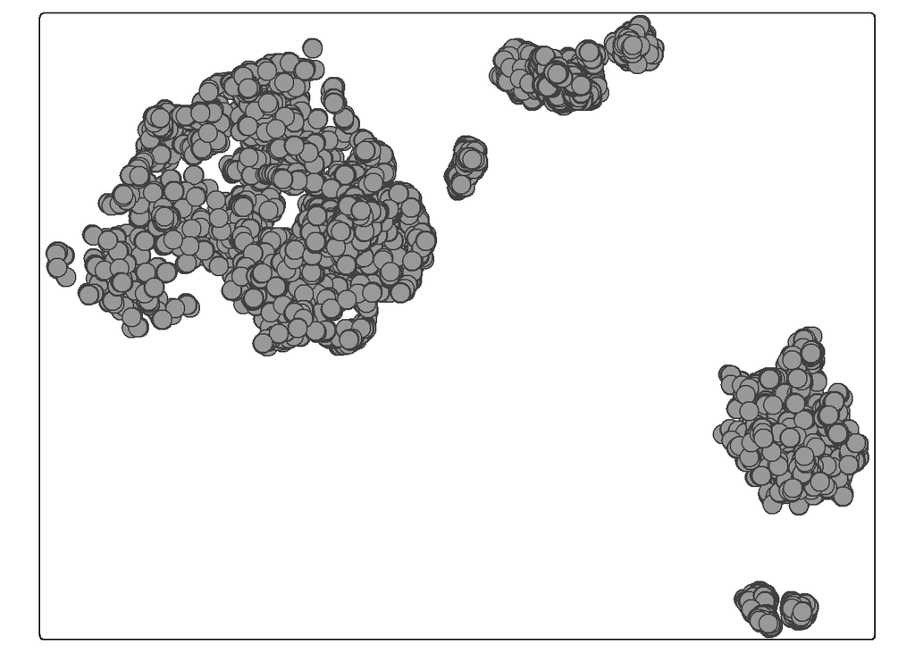

```r
qtm(streetlights_all)
```